# Statistical software for climate: extRemes, climextRemes, and NIMBLE

Part 3: NIMBLE for extremes

Chris Paciorek

July 2019

# Doing EVA in NIMBLE

NIMBLE provides a variety of distributions, as seen in Section 5.2.3 of the [NIMBLE manual](https://r-nimble.org/html_manual/cha-writing-models.html#writing-models).

However, there are lots of other probability distributions out there that you might want to use. So NIMBLE allows you to code up your own distribution and then use it in BUGS code.

In order to do EVA in NIMBLE we need additional, non-standard distributions, such as the GEV distribution or the point process-based distribution for POT analysis.

We’ll use the GEV distribution here.

# Writing your own distribution

Here’s what you would do to code up your own GEV distribution and make it available in BUGS code.

First we write nimbleFunctions for the density and simulation functions. Note the naming is analogous to how probability distributions are handled in R.

- The ‘d’ function should have *log* as its last argument, a binary argument for whether the log density is returned or not.
- The ‘r’ function should have *n* as its first argument but need only work for `n=1`.

```r
dgev <- nimbleFunction(
    run = function(x = double(0), mu = double(0), sigma = double(0), xi = double(0),
        log = integer(0, default = 0)) {

        returnType(double(0))
        std <- (x - mu) / sigma
        if(1 + xi*std <= 0) {
             logProb <- -Inf
        } else logProb <- -log(sigma) - (1+1/xi) * log(1 + xi * std) - (1 + xi * std)^(-1/xi)
        if(log) return(logProb)
        else return(exp(logProb))
    })

rgev <- nimbleFunction(
    run = function(n = integer(0), mu = double(0), sigma = double(0), xi = double(0)) {
        returnType(double(0))
        if(n != 1) print("rgev only allows n = 1; using n = 1.")
        u <- runif(1)
        if (xi == 0) {
           x = -log(-log(u))
        } else {
           x = ((-log(u))^(-xi) - 1.0)/xi
        }
        return (x*sigma + mu)
    })
```

The functions are written as nimbleFunctions. The NIMBLE manual has a lot of information about this, but for now a few comments:

- nimbleFunctions are written using a subset of R syntax: not all R syntax is allowed.
- We require information about the types and sizes of arguments and return values.
- nimbleFunctions can call out to arbitrary R or C/C++ code that you write for full customizability.

Strictly speaking you may not need the ‘r’ function if you are using MCMC and the samplers used don’t need to sample from the prior. For standard NIMBLE samplers, this will be the case, so you wouldn’t need `rgev`. However, we do need it because we have missing observations and `rgev` is used to impute those values during MCMC.

# A basic Bayesian EVA model

We can mimic fitting a basic Bayesian model as done in extRemes:

```r
library(extRemes)
data(Fort)
FortMax <- aggregate(Prec ~ year, data = Fort, max)
gev_model <- fevd(FortMax$Prec, type = 'GEV')
```

```r
code <- nimbleCode({
   # likelihood
   for(i in 1:n) {
      y[i] ~ dgev(mu, sigma, xi)
   }

   # priors
   mu ~ dflat()
   sigma ~ dunif(0, 100)
   xi ~ dunif(-1, 1)
})

inits <- as.list(gev_model$results$par)
names(inits) <- c('mu', 'sigma', 'xi')
model <- nimbleModel(code, data = list(y = FortMax$Prec), inits = inits,
          constants = list(n = length(FortMax$Prec)))
```

```
## defining model...
```

```
## building model...
```

```
## setting data and initial values...
```

```
## running calculate on model (any error reports that follow may simply reflect missing values in model variables) ...
## checking model sizes and dimensions...
## model building finished.
```

```r
cModel <- compileNimble(model)
```

```
## compiling... this may take a minute. Use 'showCompilerOutput = TRUE' to see C++ compilation details.
## compilation finished.
```

```r
conf <- configureMCMC(model, onlySlice = TRUE)
MCMC <- buildMCMC(conf)
cMCMC <- compileNimble(MCMC, project = model)
```

```
## compiling... this may take a minute. Use 'showCompilerOutput = TRUE' to see C++ compilation details.
## compilation finished.
```

```r
samples <- runMCMC(cMCMC, niter = 1000, nburn = 100)
```

```
## running chain 1...
```

```
## |-------------|-------------|-------------|-------------|
## |-------------------------------------------------------|
```

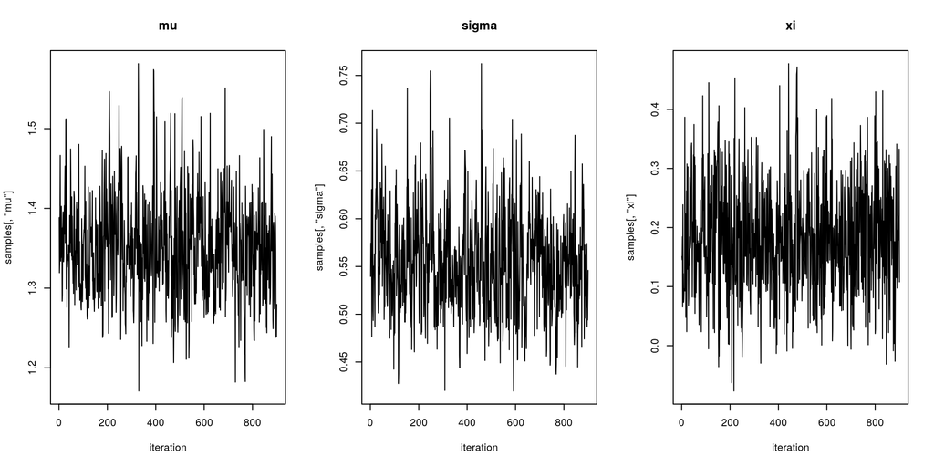

```r
par(mfrow = c(1,3))
ts.plot(samples[ , 'mu'], xlab = 'iteration', main = 'mu')
ts.plot(samples[ , 'sigma'], xlab = 'iteration', main = 'sigma')
ts.plot(samples[ , 'xi'], xlab = 'iteration', main = 'xi')
```

```r
quantile(samples[ , 'mu'], c(.025, .5, .975))
```

```
##     2.5%      50%    97.5%
## 1.239853 1.348696 1.490235
```

```r
quantile(samples[ , 'sigma'], c(.025, .5, .975))
```

```
##      2.5%       50%     97.5%
## 0.4581332 0.5514390 0.6676401
```

```r
quantile(samples[ , 'xi'], c(.025, .5, .975))
```

```
##      2.5%       50%     97.5%
## 0.0110328 0.1756824 0.3748363
```

Let’s compare to what we had from extRemes.

```r
gev_model <- fevd(FortMax$Prec, type = 'GEV')

bayesian_gev_model <- fevd(FortMax$Prec, type = 'GEV', method = 'Bayesian',
         initial = as.list(gev_model$results$par), iter = 1999)
bayesian_gev_model
```

```
##
## fevd(x = FortMax$Prec, type = "GEV", method = "Bayesian", initial = as.list(gev_model$results$par),
##     iter = 1999)
##
## [1] "Estimation Method used: Bayesian"
##
##
##  Acceptance Rates:
## log.scale     shape
## 0.4699700 0.4814815
## fevd(x = FortMax$Prec, type = "GEV", method = "Bayesian", initial = as.list(gev_model$results$par),
##     iter = 1999)
##
## [1] "Quantiles of MCMC Sample from Posterior Distribution"
##
##                 2.5% Posterior Mean     97.5%
## location  1.22189569      1.3564409 1.4928078
## scale     0.46329182      0.5587623 0.6809475
## shape    -0.01716031      0.1746914 0.4392824
##
##
##  Estimated parameter covariance matrix.
##               location     log.scale         shape
## location   0.005129798  0.0020455540 -0.0029989794
## log.scale  0.002045554  0.0030899980 -0.0004862024
## shape     -0.002998979 -0.0004862024  0.0129129307
##
##  DIC =  638.0584
```

It’s a bit more work to do the NIMBLE version, but you have much more control over the MCMC sampling, both in terms of getting a better algorithm and in terms of diagnosing problems.

And most importantly you can extend the model in small or large ways.

# A hierarchical EVA model

Now let’s use this model to analyze the California precipitation data in a similar fashion to before, but considering seasonal maxima rather than seasonal totals.

```r
code <- nimbleCode({
    for(j in 1:J) {  # stations
       for(i in 1:nYears) {  # time
           # likelihood
           y[j, i] ~ dgev(b0[j] + b1[j] * t[i],
                     exp(gamma0[j] + gamma1[j] * t[i]),
                     xi[j])  # would be hard to estimate variation over time
       }

       # random effects
       b0[j] ~ dnorm(mu0, sd = sigma0)
       b1[j] ~ dnorm(mu1, sd = sigma1)
       gamma0[j] ~ dnorm(theta0, sd = tau0)
       gamma1[j] ~ dnorm(theta1, sd = tau1)
       xi[j] ~ dnorm(eta, sd = zeta)
   }

   # hyperpriors
   mu0 ~ dflat()
   mu1 ~ dflat()
   theta0 ~ dflat()
   theta1 ~ dflat()
   eta ~ dunif(-1, 1)
   ## see Gelman (2006) for non-informative priors for variance components
   sigma0 ~ dunif(0, 100)
   sigma1 ~ dunif(0, 100)
   tau0 ~ dunif(0, 100)
   tau1 ~ dunif(0, 100)
   zeta ~ dunif(0, 2)
})
```

# Let’s set up the model as before

```r
load('precip.Rda')
y <- as.matrix(maxs[ , 5:ncol(maxs)])
n <- as.matrix(cnts[ , 5:ncol(cnts)])
y[n < 86] <- NA
y <- y / 10  # data now in cm not mm

nYears <- ncol(y)
J <- nrow(y)
tt <- 1950:2017
tt <- tt - mean(tt)

consts <- list(J = J, nYears = nYears, t = tt)
data <- list(y = y)

set.seed(1)
inits <- list(b0 = apply(y, 1, mean, na.rm = TRUE), b1 = rnorm(J, 0, 0.01),
                 gamma0 = log(apply(y, 1, sd, na.rm = TRUE)),
                 gamma1 = rnorm(J, 0, .002),
                 mu0 = mean(y, na.rm = TRUE), mu1 = 0,
                 theta0 = log(sd(y, na.rm = TRUE)), xi = rnorm(J, 0.1, 0.1),
                 theta1 = 0, sigma0 = 2, sigma1 = 0.01,
                 tau0 = .1, tau1 = .002, eta = 0.1, zeta = 0.1)

model <- nimbleModel(code,
          data = data, constants = consts, inits = inits)
```

```
## defining model...
```

```
## building model...
```

```
## setting data and initial values...
```

```
## running calculate on model (any error reports that follow may simply reflect missing values in model variables) ... Error in if (1 + xi * std <= 0) { : missing value where TRUE/FALSE needed
##
## checking model sizes and dimensions... This model is not fully initialized. This is not an error. To see which variables are not initialized, use model$initializeInfo(). For more information on model initialization, see help(modelInitialization).
## model building finished.
```

That error is caused by having an NA in the condition of `if()`. In NIMBLE it’s generally caused by having a parameter with an NA. (In the next version of NIMBLE, we will suppress the message and just have the logProb be -Inf…) In this case it is because the GEV distribution density checks a condition involving the data values.

In this case the issue is the NA’s in the y values. We’ll ignore this for now as the MCMC will simulate into those model nodes (NIMBLE treats missing data as unknown parameters).

```r
model$initializeInfo()
```

```
## Missing values (NAs) or non-finite values were found in model variables: y. This is not an error, but some or all variables may need to be initialized for certain algorithms to operate properly. For more information on model initialization, see help(modelInitialization).
```

```r
sum(!model$isData('y'))
```

```
## [1] 85
```

```r
sum(is.na(y))
```

```
## [1] 85
```

```r
cModel <- compileNimble(model)
```

```
## compiling... this may take a minute. Use 'showCompilerOutput = TRUE' to see C++ compilation details.
```

```
## compilation finished.
```

```r
cModel$calculate()
```

```
## [1] NA
```

```r
conf <- configureMCMC(model)
conf$addMonitors(c('b0','b1','gamma0','gamma1','xi'))
```

```
## thin = 1: mu0, mu1, theta0, theta1, eta, sigma0, sigma1, tau0, tau1, zeta, b0, b1, gamma0, gamma1, xi
```

```r
MCMC <- buildMCMC(conf)
cMCMC <- compileNimble(MCMC, project = model)
```

```
## compiling... this may take a minute. Use 'showCompilerOutput = TRUE' to see C++ compilation details.
## compilation finished.
```

```r
niter <- 11000
nburn <- 1000
thin <- 20
set.seed(1)

samples <- runMCMC(cMCMC, niter = niter, nburnin = nburn, thin = thin, setSeed = 1)
```

```
## runMCMC's handling of nburnin changed in nimble version 0.6-11. Previously, nburnin samples were discarded *post-thinning*.  Now nburnin samples are discarded *pre-thinning*.  The number of samples returned will be floor((niter-nburnin)/thin).
```

```
## running chain 1...
```

```
## |-------------|-------------|-------------|-------------|
## |-------------------------------------------------------|
```

Let’s see how that went.

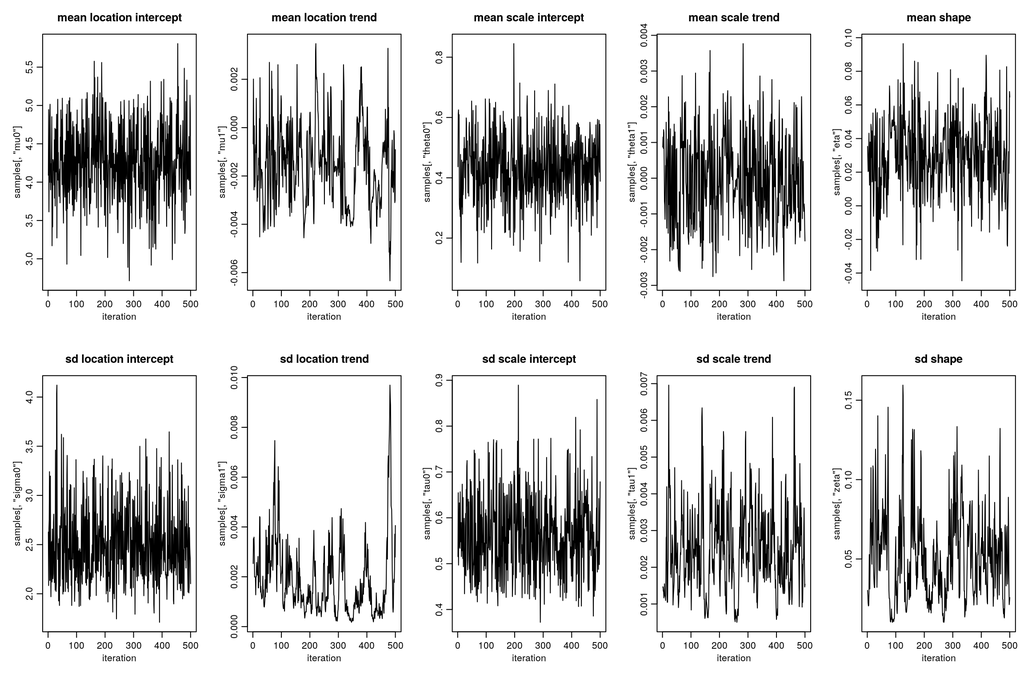

```r
par(mfcol = c(2,5), mai = c(.6, .5, .4, .1), mgp = c(1.8, 0.7, 0), fig.width=12, fig.height=5)
ts.plot(samples[ , 'mu0'], xlab = 'iteration', main = 'mean location intercept')
ts.plot(samples[ , 'sigma0'], xlab = 'iteration', main = 'sd location intercept')
ts.plot(samples[ , 'mu1'], xlab = 'iteration', main = 'mean location trend')
ts.plot(samples[ , 'sigma1'], xlab = 'iteration', main = 'sd location trend')
ts.plot(samples[ , 'theta0'], xlab = 'iteration', main = 'mean scale intercept')
ts.plot(samples[ , 'tau0'], xlab = 'iteration', main = 'sd scale intercept')
ts.plot(samples[ , 'theta1'], xlab = 'iteration', main = 'mean scale trend')
ts.plot(samples[ , 'tau1'], xlab = 'iteration', main = 'sd scale trend')
ts.plot(samples[ , 'eta'], xlab = 'iteration', main = 'mean shape')
ts.plot(samples[ , 'zeta'], xlab = 'iteration', main = 'sd shape')
```

Here are the trend parameters for the location parameter for some of the stations.

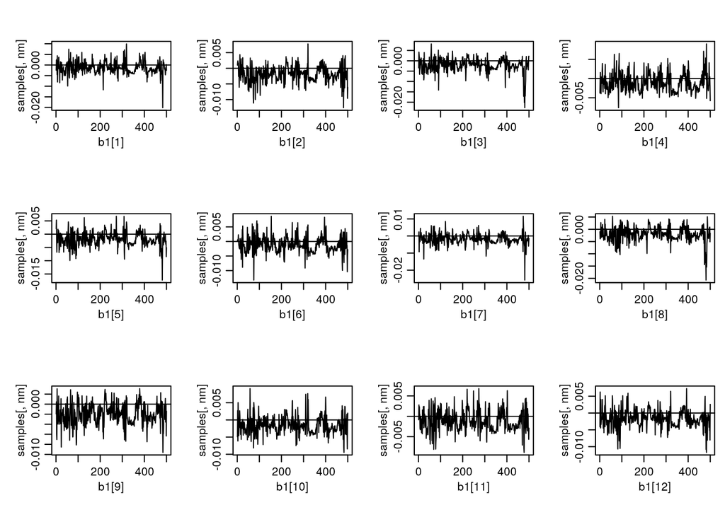

```r
par(mfrow = c(3, 4), mai = c(.6, .5, .4, .1), mgp = c(1.8, 0.7, 0))
for(j in 1:12) {
      nm <- paste0('b1[', j, ']')
      ts.plot(samples[ , nm], xlab = nm)
      abline(h = 0)
}
```

Here are the trend parameters for the scale parameter for some of the stations.

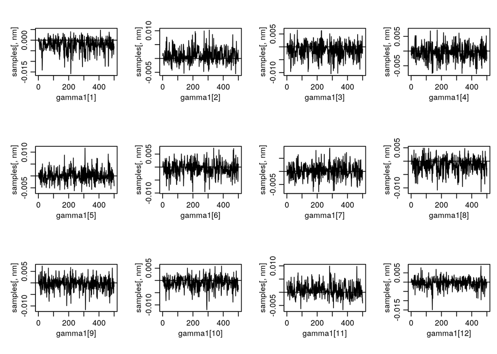

```r
par(mfrow = c(3, 4), mai = c(.6, .5, .4, .1), mgp = c(1.8, 0.7, 0))
for(j in 1:12) {
      nm <- paste0('gamma1[', j, ']')
      ts.plot(samples[ , nm], xlab = nm)
      abline(h = 0)
}
```